# DDSAnalytics_CaseStudy_SaloniBhatia

Saloni Bhatia

August 18, 2019

## **Introduction**

In response to DDSAnalytics request for support in identifying factors contributing to attrition and any other possible trends associated with job roles within the work force and provided data set. In the conduct of analysis, I have employed a number of exploratory data analysis techniques and are confident that we have unmasked some significant insights into these requests.

## **Analysis Repository**

#### Downloading and Importing the Data

```r
# getwd()
#Downloading the data
# library(downloader)


# list.files()
#Importing the raw case study file

df_Attrition <-read.csv("C:/SMU/DoingDatascience/Casestudy2/CaseStudy2-data.csv", header = TRUE, sep = ",")

head(df_Attrition)
```

```
##   ID Age Attrition    BusinessTravel DailyRate             Department
## 1  1  32        No     Travel_Rarely       117                  Sales
## 2  2  40        No     Travel_Rarely      1308 Research & Development
## 3  3  35        No Travel_Frequently       200 Research & Development
## 4  4  32        No     Travel_Rarely       801                  Sales
## 5  5  24        No Travel_Frequently       567 Research & Development
## 6  6  27        No Travel_Frequently       294 Research & Development
##   DistanceFromHome Education   EducationField EmployeeCount EmployeeNumber
## 1               13         4    Life Sciences             1            859
## 2               14         3          Medical             1           1128
## 3               18         2    Life Sciences             1           1412
## 4                1         4        Marketing             1           2016
## 5                2         1 Technical Degree             1           1646
## 6               10         2    Life Sciences             1            733
##   EnvironmentSatisfaction Gender HourlyRate JobInvolvement JobLevel
```

[output cut: 48 more lines]

```r
str(df_Attrition)
```

```
## 'data.frame':    870 obs. of  36 variables:
##  $ ID                      : int  1 2 3 4 5 6 7 8 9 10 ...
##  $ Age                     : int  32 40 35 32 24 27 41 37 34 34 ...
##  $ Attrition               : Factor w/ 2 levels "No","Yes": 1 1 1 1 1 1 1 1 1 1 ...
##  $ BusinessTravel          : Factor w/ 3 levels "Non-Travel","Travel_Frequently",..: 3 3 2 3 2 2 3 3 3 2 ...
##  $ DailyRate               : int  117 1308 200 801 567 294 1283 309 1333 653 ...
##  $ Department              : Factor w/ 3 levels "Human Resources",..: 3 2 2 3 2 2 2 3 3 2 ...
##  $ DistanceFromHome        : int  13 14 18 1 2 10 5 10 10 10 ...
##  $ Education               : int  4 3 2 4 1 2 5 4 4 4 ...
##  $ EducationField          : Factor w/ 6 levels "Human Resources",..: 2 4 2 3 6 2 4 2 2 6 ...
##  $ EmployeeCount           : int  1 1 1 1 1 1 1 1 1 1 ...
##  $ EmployeeNumber          : int  859 1128 1412 2016 1646 733 1448 1105 1055 1597 ...
##  $ EnvironmentSatisfaction : int  2 3 3 3 1 4 2 4 3 4 ...
##  $ Gender                  : Factor w/ 2 levels "Female","Male": 2 2 2 1 1 2 2 1 1 2 ...
##  $ HourlyRate              : int  73 44 60 48 32 32 90 88 87 92 ...
```

[output cut: 22 more lines]

```r
#Importing Attrition Validation File

df_AttritionPrediction <-read.csv("C:/SMU/DoingDatascience/Casestudy2/CaseStudy2CompSet No Attrition.csv", header = TRUE, sep = ",")

str(df_AttritionPrediction)
```

```
## 'data.frame':    300 obs. of  35 variables:
##  $ ID                      : int  1171 1172 1173 1174 1175 1176 1177 1178 1179 1180 ...
##  $ Age                     : int  35 33 26 55 29 51 52 39 31 31 ...
##  $ BusinessTravel          : Factor w/ 3 levels "Non-Travel","Travel_Frequently",..: 3 3 3 3 3 2 1 3 3 2 ...
##  $ DailyRate               : int  750 147 1330 1311 1246 1456 585 1387 1062 534 ...
##  $ Department              : Factor w/ 3 levels "Human Resources",..: 2 1 2 2 3 2 3 2 2 2 ...
##  $ DistanceFromHome        : int  28 2 21 2 19 1 29 10 24 20 ...
##  $ Education               : int  3 3 3 3 3 4 4 5 3 3 ...
##  $ EducationField          : Factor w/ 6 levels "Human Resources",..: 2 1 4 2 2 4 2 4 4 2 ...
##  $ EmployeeCount           : int  1 1 1 1 1 1 1 1 1 1 ...
##  $ EmployeeNumber          : int  1596 1207 1107 505 1497 145 2019 1618 1252 587 ...
##  $ EnvironmentSatisfaction : int  2 2 1 3 3 1 1 2 3 1 ...
##  $ Gender                  : Factor w/ 2 levels "Female","Male": 2 2 2 1 2 1 2 2 1 2 ...
##  $ HourlyRate              : int  46 99 37 97 77 30 40 76 96 66 ...
##  $ JobInvolvement          : int  4 3 3 3 2 2 3 3 2 3 ...
```

[output cut: 21 more lines]

```r
#Importing Salary Prediction File

df_IncomePrediction <-read.csv("C:/SMU/DoingDatascience/Casestudy2/CaseStudy2CompSet No Salary.csv", header = TRUE)

str(df_IncomePrediction)
```

```
## 'data.frame':    300 obs. of  35 variables:
##  $ ï..ID                   : int  871 872 873 874 875 876 877 878 879 880 ...
##  $ Age                     : int  43 33 55 36 27 39 33 21 30 51 ...
##  $ Attrition               : Factor w/ 2 levels "No","Yes": 1 1 2 1 1 2 1 2 1 1 ...
##  $ BusinessTravel          : Factor w/ 3 levels "Non-Travel","Travel_Frequently",..: 2 3 3 1 3 3 1 2 2 3 ...
##  $ DailyRate               : int  1422 461 267 1351 1302 895 750 251 1312 1405 ...
##  $ Department              : Factor w/ 3 levels "Human Resources",..: 3 2 3 2 2 3 3 2 2 2 ...
##  $ DistanceFromHome        : int  2 13 13 9 19 5 22 10 23 11 ...
##  $ Education               : int  4 1 4 4 3 3 2 2 3 2 ...
##  $ EducationField          : Factor w/ 6 levels "Human Resources",..: 2 2 3 2 5 6 3 2 2 6 ...
##  $ EmployeeCount           : int  1 1 1 1 1 1 1 1 1 1 ...
##  $ EmployeeNumber          : int  1849 995 1372 1949 1619 42 160 1279 159 1367 ...
##  $ EnvironmentSatisfaction : int  1 2 1 1 4 4 3 1 1 4 ...
##  $ Gender                  : Factor w/ 2 levels "Female","Male": 2 1 2 2 2 2 2 1 2 1 ...
##  $ HourlyRate              : int  92 53 85 66 67 56 95 45 96 82 ...
```

[output cut: 21 more lines]

```r
head(df_IncomePrediction)
```

```
##   ï..ID Age Attrition    BusinessTravel DailyRate             Department
## 1   871  43        No Travel_Frequently      1422                  Sales
## 2   872  33        No     Travel_Rarely       461 Research & Development
## 3   873  55       Yes     Travel_Rarely       267                  Sales
## 4   874  36        No        Non-Travel      1351 Research & Development
## 5   875  27        No     Travel_Rarely      1302 Research & Development
## 6   876  39       Yes     Travel_Rarely       895                  Sales
##   DistanceFromHome Education   EducationField EmployeeCount EmployeeNumber
## 1                2         4    Life Sciences             1           1849
## 2               13         1    Life Sciences             1            995
## 3               13         4        Marketing             1           1372
## 4                9         4    Life Sciences             1           1949
## 5               19         3            Other             1           1619
## 6                5         3 Technical Degree             1             42
##   EnvironmentSatisfaction Gender HourlyRate JobInvolvement JobLevel
```

[output cut: 41 more lines]

## Initial Exploratory Plots

```r
library(manipulate)
library(tidyverse)
```

```r
library(dplyr)
library(ggplot2)
library(purrr)
library(plyr)
library(scales)
library(magrittr)
library(knitr)
library(kableExtra)
library(caret)
```

## **Workforce Overview / Initial Statistics**

Being unfamiliar with the DDSAnalytics workforce or structure, began analysis with a robust examination of the operating construct, workforce composition, job roles, departments and other aspects contained within the data. Let’s begin cleaning the data first and casting datatypes.

## Cleaning Datasets

#### Several variables classified as integars could also be seen as categorical and will be converted to factor types

```r
##Removing Over18 variable since only 1 level of factor & EmployeeCount & StandardHours

df_Attrition2 <- df_Attrition[,-c(1, 11, 23, 28)]

str(df_Attrition2)
```

```
## 'data.frame':    870 obs. of  32 variables:
##  $ Age                     : int  32 40 35 32 24 27 41 37 34 34 ...
##  $ Attrition               : Factor w/ 2 levels "No","Yes": 1 1 1 1 1 1 1 1 1 1 ...
##  $ BusinessTravel          : Factor w/ 3 levels "Non-Travel","Travel_Frequently",..: 3 3 2 3 2 2 3 3 3 2 ...
##  $ DailyRate               : int  117 1308 200 801 567 294 1283 309 1333 653 ...
##  $ Department              : Factor w/ 3 levels "Human Resources",..: 3 2 2 3 2 2 2 3 3 2 ...
##  $ DistanceFromHome        : int  13 14 18 1 2 10 5 10 10 10 ...
##  $ Education               : int  4 3 2 4 1 2 5 4 4 4 ...
##  $ EducationField          : Factor w/ 6 levels "Human Resources",..: 2 4 2 3 6 2 4 2 2 6 ...
##  $ EmployeeCount           : int  1 1 1 1 1 1 1 1 1 1 ...
##  $ EnvironmentSatisfaction : int  2 3 3 3 1 4 2 4 3 4 ...
##  $ Gender                  : Factor w/ 2 levels "Female","Male": 2 2 2 1 1 2 2 1 1 2 ...
##  $ HourlyRate              : int  73 44 60 48 32 32 90 88 87 92 ...
##  $ JobInvolvement          : int  3 2 3 3 3 3 4 2 3 2 ...
##  $ JobLevel                : int  2 5 3 3 1 3 1 2 1 2 ...
```

[output cut: 18 more lines]

```r
#Add Attrition Code

df_Attrition2$AttritionCode <- 0

df_Attrition2[df_Attrition2$Attrition == "Yes", ]$AttritionCode <- 1



#Casting all Rating Variables as Factors

df_Attrition2$Education <- as.factor(df_Attrition2$Education)

df_Attrition2$EnvironmentSatisfaction <- as.factor(df_Attrition2$EnvironmentSatisfaction)

df_Attrition2$JobInvolvement <- as.factor(df_Attrition2$JobInvolvement)

df_Attrition2$JobLevel <- as.factor(df_Attrition2$JobLevel)

df_Attrition2$JobSatisfaction <- as.factor(df_Attrition2$JobSatisfaction)

df_Attrition2$PerformanceRating <- as.factor(df_Attrition2$PerformanceRating)

df_Attrition2$RelationshipSatisfaction <- as.factor(df_Attrition2$RelationshipSatisfaction)

df_Attrition2$StockOptionLevel <- as.factor(df_Attrition2$StockOptionLevel)

df_Attrition2$TrainingTimesLastYear <- as.factor(df_Attrition2$TrainingTimesLastYear)

df_Attrition2$WorkLifeBalance <- as.factor(df_Attrition2$WorkLifeBalance)

#Checking for NAs
colSums(is.na(df_Attrition2))
```

```
##                      Age                Attrition           BusinessTravel
##                        0                        0                        0
##                DailyRate               Department         DistanceFromHome
##                        0                        0                        0
##                Education           EducationField            EmployeeCount
##                        0                        0                        0
##  EnvironmentSatisfaction                   Gender               HourlyRate
##                        0                        0                        0
##           JobInvolvement                 JobLevel                  JobRole
##                        0                        0                        0
##          JobSatisfaction            MaritalStatus            MonthlyIncome
##                        0                        0                        0
##              MonthlyRate       NumCompaniesWorked                 OverTime
##                        0                        0                        0
##        PercentSalaryHike        PerformanceRating RelationshipSatisfaction
##                        0                        0                        0
##         StockOptionLevel        TotalWorkingYears    TrainingTimesLastYear
##                        0                        0                        0
##          WorkLifeBalance           YearsAtCompany       YearsInCurrentRole
##                        0                        0                        0
##  YearsSinceLastPromotion     YearsWithCurrManager            AttritionCode
##                        0                        0                        0
```

```r
#cleaning Validation Table

##Removing Over18 variable since only 1 level of factor & EmployeeCount & StandardHours

df_AttritionPrediction <- df_AttritionPrediction[,-c( 10, 22, 27)]

str(df_AttritionPrediction)
```

```
## 'data.frame':    300 obs. of  32 variables:
##  $ ID                      : int  1171 1172 1173 1174 1175 1176 1177 1178 1179 1180 ...
##  $ Age                     : int  35 33 26 55 29 51 52 39 31 31 ...
##  $ BusinessTravel          : Factor w/ 3 levels "Non-Travel","Travel_Frequently",..: 3 3 3 3 3 2 1 3 3 2 ...
##  $ DailyRate               : int  750 147 1330 1311 1246 1456 585 1387 1062 534 ...
##  $ Department              : Factor w/ 3 levels "Human Resources",..: 2 1 2 2 3 2 3 2 2 2 ...
##  $ DistanceFromHome        : int  28 2 21 2 19 1 29 10 24 20 ...
##  $ Education               : int  3 3 3 3 3 4 4 5 3 3 ...
##  $ EducationField          : Factor w/ 6 levels "Human Resources",..: 2 1 4 2 2 4 2 4 4 2 ...
##  $ EmployeeCount           : int  1 1 1 1 1 1 1 1 1 1 ...
##  $ EnvironmentSatisfaction : int  2 2 1 3 3 1 1 2 3 1 ...
##  $ Gender                  : Factor w/ 2 levels "Female","Male": 2 2 2 1 2 1 2 2 1 2 ...
##  $ HourlyRate              : int  46 99 37 97 77 30 40 76 96 66 ...
##  $ JobInvolvement          : int  4 3 3 3 2 2 3 3 2 3 ...
##  $ JobLevel                : int  2 1 1 4 2 3 1 2 2 3 ...
```

[output cut: 18 more lines]

```r
#Casting Rating Variables as Factors

df_AttritionPrediction$Education <- as.factor(df_AttritionPrediction$Education)

df_AttritionPrediction$EnvironmentSatisfaction <- as.factor(df_AttritionPrediction$EnvironmentSatisfaction)

df_AttritionPrediction$JobInvolvement <- as.factor(df_AttritionPrediction$JobInvolvement)

df_AttritionPrediction$JobLevel <- as.factor(df_AttritionPrediction$JobLevel)

df_AttritionPrediction$JobSatisfaction <- as.factor(df_AttritionPrediction$JobSatisfaction)

df_AttritionPrediction$PerformanceRating <- as.factor(df_AttritionPrediction$PerformanceRating)

df_AttritionPrediction$RelationshipSatisfaction <- as.factor(df_AttritionPrediction$RelationshipSatisfaction)

df_AttritionPrediction$StockOptionLevel <- as.factor(df_AttritionPrediction$StockOptionLevel)

df_AttritionPrediction$TrainingTimesLastYear <- as.factor(df_AttritionPrediction$TrainingTimesLastYear)

df_AttritionPrediction$WorkLifeBalance <- as.factor(df_AttritionPrediction$WorkLifeBalance)



#cleaning Prediction File

##Removing Over18 variable since only 1 level of factor & EmployeeCount & StandardHours

df_IncomePrediction <- df_IncomePrediction[,-c(  11, 22, 27)]

str(df_IncomePrediction)
```

```
## 'data.frame':    300 obs. of  32 variables:
##  $ ï..ID                   : int  871 872 873 874 875 876 877 878 879 880 ...
##  $ Age                     : int  43 33 55 36 27 39 33 21 30 51 ...
##  $ Attrition               : Factor w/ 2 levels "No","Yes": 1 1 2 1 1 2 1 2 1 1 ...
##  $ BusinessTravel          : Factor w/ 3 levels "Non-Travel","Travel_Frequently",..: 2 3 3 1 3 3 1 2 2 3 ...
##  $ DailyRate               : int  1422 461 267 1351 1302 895 750 251 1312 1405 ...
##  $ Department              : Factor w/ 3 levels "Human Resources",..: 3 2 3 2 2 3 3 2 2 2 ...
##  $ DistanceFromHome        : int  2 13 13 9 19 5 22 10 23 11 ...
##  $ Education               : int  4 1 4 4 3 3 2 2 3 2 ...
##  $ EducationField          : Factor w/ 6 levels "Human Resources",..: 2 2 3 2 5 6 3 2 2 6 ...
##  $ EmployeeCount           : int  1 1 1 1 1 1 1 1 1 1 ...
##  $ EnvironmentSatisfaction : int  1 2 1 1 4 4 3 1 1 4 ...
##  $ Gender                  : Factor w/ 2 levels "Female","Male": 2 1 2 2 2 2 2 1 2 1 ...
##  $ HourlyRate              : int  92 53 85 66 67 56 95 45 96 82 ...
##  $ JobInvolvement          : int  3 3 4 4 2 3 3 2 1 2 ...
```

[output cut: 18 more lines]

```r
#Casting Rating Variables as Factors

df_IncomePrediction$Education <- as.factor(df_IncomePrediction$Education)

df_IncomePrediction$EnvironmentSatisfaction <- as.factor(df_IncomePrediction$EnvironmentSatisfaction)

df_IncomePrediction$JobInvolvement <- as.factor(df_IncomePrediction$JobInvolvement)

df_IncomePrediction$JobLevel <- as.factor(df_IncomePrediction$JobLevel)

df_IncomePrediction$JobSatisfaction <- as.factor(df_IncomePrediction$JobSatisfaction)

df_IncomePrediction$PerformanceRating <- as.factor(df_IncomePrediction$PerformanceRating)

df_IncomePrediction$RelationshipSatisfaction <- as.factor(df_IncomePrediction$RelationshipSatisfaction)

df_IncomePrediction$StockOptionLevel <- as.factor(df_IncomePrediction$StockOptionLevel)

df_IncomePrediction$TrainingTimesLastYear <- as.factor(df_IncomePrediction$TrainingTimesLastYear)

df_IncomePrediction$WorkLifeBalance <- as.factor(df_IncomePrediction$WorkLifeBalance)
```

# Analysis

The data contained records for *870* current and former employees of DDSAnalytics. These records broke down as follows.

| Department | Employee Count | % of Total Employees |
| --- | --- | --- |
| Human Resources | 35 | 4.0% |
| Research & Development | 562 | 64.6% |
| Sales | 273 | 31.4% |

## Correlation Plots

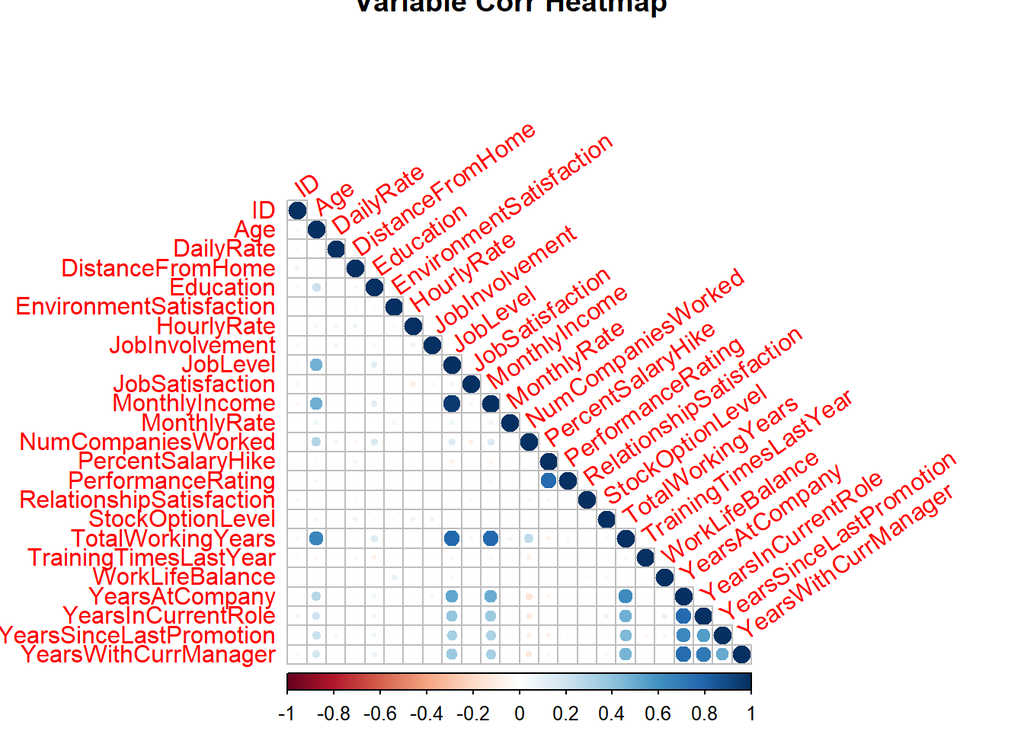

```r
#Correlation Plots

library(corrplot)

#Only Integer Variables

EmpCorrelations <- cor(df_Attrition2 %>% keep(is.integer))
#corrplot(EmpCorrelations, type = "lower", diag = TRUE,title="Variable Corr Heatmap",tl.srt=45)

#All Variables

EmpCorrelationsAll <- cor(df_Attrition[,-c( 10, 11, 23, 28)] %>% keep(is.integer))

corrplot(EmpCorrelationsAll, type = "lower", title="Variable Corr Heatmap",tl.srt=35)
```

## Attrition Frequencies

```r
#Creating Attrition Proportion Tables

TotalAttr <- table(df_Attrition2$Attrition)

BusTravAttr <- table(df_Attrition2$BusinessTravel,df_Attrition2$Attrition)

DeptAttr <- table(df_Attrition2$Department,df_Attrition2$Attrition)

EduFieldAttr <- table(df_Attrition2$EducationField,df_Attrition2$Attrition)

GenderAttr <- table(df_Attrition2$Gender,df_Attrition2$Attrition)

RoleAttr <- table(df_Attrition2$JobRole,df_Attrition2$Attrition)

MaritalAttr <- table(df_Attrition2$MaritalStatus,df_Attrition2$Attrition)

OverTimeAttr <- table(df_Attrition2$OverTime,df_Attrition2$Attrition)

EducationAttr <- table(df_Attrition2$Education,df_Attrition2$Attrition)

EnvirSatAttr <- table(df_Attrition2$EnvironmentSatisfaction,df_Attrition2$Attrition)

JobInvAttr <- table(df_Attrition2$JobInvolvement,df_Attrition2$Attrition)

JobLevAttr <- table(df_Attrition2$JobLevel,df_Attrition2$Attrition)

JobSatAttr <- table(df_Attrition2$JobSatisfaction,df_Attrition2$Attrition)

PerRatAttr <- table(df_Attrition2$PerformanceRating,df_Attrition2$Attrition)

RelSatAttr <- table(df_Attrition2$RelationshipSatisfaction,df_Attrition2$Attrition)

StockAttr <- table(df_Attrition2$StockOptionLevel,df_Attrition2$Attrition)

NumCompaniesWorkedAttr <- table(df_Attrition2$NumCompaniesWorked,df_Attrition2$Attrition)

WorkLifeAttr <- table(df_Attrition2$WorkLifeBalance,df_Attrition2$Attrition)


#Getting Percentages

TotalAttr_Prop <- prop.table(TotalAttr)

BusTravAttr_Prop <- data.frame(prop.table(BusTravAttr, 1))

DeptAttr_Prop <- data.frame(prop.table(DeptAttr, 1) )

EduFieldAttrAttr_Prop <- data.frame(prop.table(EduFieldAttr, 1) )

GenderAttr_Prop <- data.frame(prop.table(GenderAttr, 1))

RoleAttr_Prop <- data.frame(prop.table(RoleAttr, 1) )

MaritalAttr_Prop <- data.frame(prop.table(MaritalAttr, 1))

OverTimeAttr_Prop <- data.frame(prop.table(OverTimeAttr, 1))


EducationAttr_Prop <- data.frame(prop.table(EducationAttr, 1))

EnvirSatAttr_Prop <- data.frame(prop.table(EnvirSatAttr, 1))

JobInvAttr_Prop <- data.frame(prop.table(JobInvAttr, 1))

JobLevAttr_Prop <- data.frame(prop.table(JobLevAttr, 1))

JobSatAttr_Prop <- data.frame(prop.table(JobSatAttr, 1))

PerRatAttr_Prop <- data.frame(prop.table(PerRatAttr, 1))

RelSatAttr_Prop <- data.frame(prop.table(RelSatAttr, 1))

StockAttr_Prop <- data.frame(prop.table(StockAttr, 1))

NumCompaniesWorkedAttr_Prop <- data.frame(prop.table(NumCompaniesWorkedAttr, 1))

WorkLifeAttr_Prop <- data.frame(prop.table(WorkLifeAttr, 1))



####Testing significance of difference in attrition between levels of each variable
#"prop.test" can be used for testing the null that the proportions (probabilities of success) in several groups are the same, or that they equal certain given values. Significance is determined when Pvalue <=0.05.

####A Chi-Squared test was used to compare the attrition rate between levels of each variable and test for significances

prop.test(BusTravAttr, correct=FALSE) #P-value < 0.05
```

```
##
##  3-sample test for equality of proportions without continuity
##  correction
##
## data:  BusTravAttr
## X-squared = 5.9945, df = 2, p-value = 0.04993
## alternative hypothesis: two.sided
## sample estimates:
##    prop 1    prop 2    prop 3
## 0.8829787 0.7784810 0.8478964
```

```r
prop.test(DeptAttr, correct=FALSE) #P-value < 0.05
```

```
##
##  3-sample test for equality of proportions without continuity
##  correction
##
## data:  DeptAttr
## X-squared = 9.329, df = 2, p-value = 0.009424
## alternative hypothesis: two.sided
## sample estimates:
##    prop 1    prop 2    prop 3
## 0.8285714 0.8665480 0.7838828
```

```r
prop.test(EduFieldAttr, correct=FALSE) ##P-value > 0.05
```

```
##
##  6-sample test for equality of proportions without continuity
##  correction
##
## data:  EduFieldAttr
## X-squared = 6.4114, df = 5, p-value = 0.2682
## alternative hypothesis: two.sided
## sample estimates:
##    prop 1    prop 2    prop 3    prop 4    prop 5    prop 6
## 0.7333333 0.8519553 0.8000000 0.8629630 0.8269231 0.7733333
```

```r
prop.test(GenderAttr, correct=FALSE) #P-value > 0.05
```

```
##
##  2-sample test for equality of proportions without continuity
##  correction
##
## data:  GenderAttr
## X-squared = 0.55469, df = 1, p-value = 0.4564
## alternative hypothesis: two.sided
## 95 percent confidence interval:
##  -0.03035720  0.06813147
## sample estimates:
##    prop 1    prop 2
## 0.8502825 0.8313953
```

```r
prop.test(RoleAttr, correct=FALSE) ##P-value < 0.05
```

```
##
##  9-sample test for equality of proportions without continuity
##  correction
##
## data:  RoleAttr
## X-squared = 60.543, df = 8, p-value = 3.647e-10
## alternative hypothesis: two.sided
## sample estimates:
##    prop 1    prop 2    prop 3    prop 4    prop 5    prop 6    prop 7
## 0.8947368 0.7777778 0.8039216 0.9215686 0.9770115 0.9803922 0.8139535
##    prop 8    prop 9
## 0.8350000 0.5471698
```

```r
prop.test(MaritalAttr, correct=FALSE) #P-value < 0.05
```

```
##
##  3-sample test for equality of proportions without continuity
##  correction
##
## data:  MaritalAttr
## X-squared = 34.406, df = 2, p-value = 3.379e-08
## alternative hypothesis: two.sided
## sample estimates:
##    prop 1    prop 2    prop 3
## 0.9371728 0.8585366 0.7397770
```

```r
prop.test(OverTimeAttr, correct=FALSE) #P-value < 0.05
```

```
##
##  2-sample test for equality of proportions without continuity
##  correction
##
## data:  OverTimeAttr
## X-squared = 64.383, df = 1, p-value = 1.024e-15
## alternative hypothesis: two.sided
## 95 percent confidence interval:
##  0.1583412 0.2824046
## sample estimates:
##    prop 1    prop 2
## 0.9029126 0.6825397
```

```r
prop.test(EducationAttr, correct=FALSE) ##P-value > 0.05
```

```
##
##  5-sample test for equality of proportions without continuity
##  correction
##
## data:  EducationAttr
## X-squared = 2.6143, df = 4, p-value = 0.6243
## alternative hypothesis: two.sided
## sample estimates:
##    prop 1    prop 2    prop 3    prop 4    prop 5
## 0.8163265 0.8241758 0.8302469 0.8666667 0.8846154
```

```r
prop.test(EnvirSatAttr, correct=FALSE) #P-value < 0.05
```

```
##
##  4-sample test for equality of proportions without continuity
##  correction
##
## data:  EnvirSatAttr
## X-squared = 11.231, df = 3, p-value = 0.01054
## alternative hypothesis: two.sided
## sample estimates:
##    prop 1    prop 2    prop 3    prop 4
## 0.7558140 0.8651685 0.8643411 0.8511450
```

```r
prop.test(JobInvAttr, correct=FALSE) #P-value < 0.05
```

```
##
##  4-sample test for equality of proportions without continuity
##  correction
##
## data:  JobInvAttr
## X-squared = 41.465, df = 3, p-value = 5.211e-09
## alternative hypothesis: two.sided
## sample estimates:
##    prop 1    prop 2    prop 3    prop 4
## 0.5319149 0.8070175 0.8696498 0.9135802
```

```r
prop.test(JobLevAttr, correct=FALSE) #P-value < 0.05
```

```
##
##  5-sample test for equality of proportions without continuity
##  correction
##
## data:  JobLevAttr
## X-squared = 41.533, df = 4, p-value = 2.085e-08
## alternative hypothesis: two.sided
## sample estimates:
##    prop 1    prop 2    prop 3    prop 4    prop 5
## 0.7386018 0.9038462 0.8712121 0.9500000 0.8918919
```

```r
prop.test(JobSatAttr, correct=FALSE) #P-value < 0.05
```

```
##
##  4-sample test for equality of proportions without continuity
##  correction
##
## data:  JobSatAttr
## X-squared = 11.109, df = 3, p-value = 0.01115
## alternative hypothesis: two.sided
## sample estimates:
##    prop 1    prop 2    prop 3    prop 4
## 0.7877095 0.8132530 0.8307087 0.8966790
```

```r
prop.test(PerRatAttr, correct=FALSE) #P-value > 0.05
```

```
##
##  2-sample test for equality of proportions without continuity
##  correction
##
## data:  PerRatAttr
## X-squared = 0.20456, df = 1, p-value = 0.6511
## alternative hypothesis: two.sided
## 95 percent confidence interval:
##  -0.05416290  0.08557457
## sample estimates:
##    prop 1    prop 2
## 0.8414634 0.8257576
```

```r
prop.test(RelSatAttr, correct=FALSE) #P-value > 0.05
```

```
##
##  4-sample test for equality of proportions without continuity
##  correction
##
## data:  RelSatAttr
## X-squared = 3.1253, df = 3, p-value = 0.3727
## alternative hypothesis: two.sided
## sample estimates:
##    prop 1    prop 2    prop 3    prop 4
## 0.7988506 0.8421053 0.8620690 0.8409091
```

```r
prop.test(StockAttr, correct=FALSE) #P-value < 0.05
```

```
##
##  4-sample test for equality of proportions without continuity
##  correction
##
## data:  StockAttr
## X-squared = 56.245, df = 3, p-value = 3.724e-12
## alternative hypothesis: two.sided
## sample estimates:
##    prop 1    prop 2    prop 3    prop 4
## 0.7414248 0.9239437 0.9629630 0.7818182
```

```r
prop.test(NumCompaniesWorkedAttr, correct=FALSE) ##P-value < 0.05
```

```
##
##  10-sample test for equality of proportions without continuity
##  correction
##
## data:  NumCompaniesWorkedAttr
## X-squared = 20.19, df = 9, p-value = 0.01678
## alternative hypothesis: two.sided
## sample estimates:
##    prop 1    prop 2    prop 3    prop 4    prop 5    prop 6    prop 7
## 0.9009009 0.8125000 0.8783784 0.9010989 0.9176471 0.7441860 0.7692308
##    prop 8    prop 9   prop 10
## 0.7608696 0.8214286 0.7575758
```

```r
prop.test(WorkLifeAttr, correct=FALSE) #P-value < 0.05
```

```
##
##  4-sample test for equality of proportions without continuity
##  correction
##
## data:  WorkLifeAttr
## X-squared = 14.325, df = 3, p-value = 0.002495
## alternative hypothesis: two.sided
## sample estimates:
##    prop 1    prop 2    prop 3    prop 4
## 0.6458333 0.8437500 0.8496241 0.8673469
```

```r
prop.test(table(df_Attrition2$Age, df_Attrition2$Attrition), correct=FALSE) ##P-value < 0.05
```

```
##
##  43-sample test for equality of proportions without continuity
##  correction
##
## data:  table(df_Attrition2$Age, df_Attrition2$Attrition)
## X-squared = 79.178, df = 42, p-value = 0.0004559
## alternative hypothesis: two.sided
## sample estimates:
##    prop 1    prop 2    prop 3    prop 4    prop 5    prop 6    prop 7
## 0.3333333 0.4285714 0.2500000 0.6666667 0.6250000 1.0000000 0.7647059
##    prop 8    prop 9   prop 10   prop 11   prop 12   prop 13   prop 14
## 0.7647059 0.8000000 0.9090909 0.6666667 0.7073171 0.8648649 0.7435897
##   prop 15   prop 16   prop 17   prop 18   prop 19   prop 20   prop 21
## 0.8157895 0.8000000 0.8947368 0.8541667 0.8809524 0.9032258 0.9722222
##   prop 22   prop 23   prop 24   prop 25   prop 26   prop 27   prop 28
## 0.8333333 0.8965517 0.8400000 0.9655172 0.9000000 0.8888889 0.9230769
##   prop 29   prop 30   prop 31   prop 32   prop 33   prop 34   prop 35
## 0.9090909 0.8947368 0.8461538 0.9285714 0.8571429 0.9090909 0.7000000
##   prop 36   prop 37   prop 38   prop 39   prop 40   prop 41   prop 42
## 0.8571429 1.0000000 0.9166667 0.8000000 1.0000000 0.5714286 1.0000000
##   prop 43
## 1.0000000
```

```r
#prop.test(table(df_Attrition2$DailyRate, df_Attrition2$Attrition), correct=FALSE) ##P-value > 0.05

prop.test(table(df_Attrition2$DistanceFromHome, df_Attrition2$Attrition), correct=FALSE) ##P-value < 0.05
```

```
##
##  29-sample test for equality of proportions without continuity
##  correction
##
## data:  table(df_Attrition2$DistanceFromHome, df_Attrition2$Attrition)
## X-squared = 42.255, df = 28, p-value = 0.04102
## alternative hypothesis: two.sided
## sample estimates:
##    prop 1    prop 2    prop 3    prop 4    prop 5    prop 6    prop 7
## 0.8482143 0.8721805 0.8222222 0.8863636 0.8484848 0.8918919 0.8800000
##    prop 8    prop 9   prop 10   prop 11   prop 12   prop 13   prop 14
## 0.9166667 0.7800000 0.8958333 0.8750000 0.8181818 0.6363636 0.7333333
##   prop 15   prop 16   prop 17   prop 18   prop 19   prop 20   prop 21
## 0.8461538 0.8000000 0.8571429 0.8750000 0.8000000 0.7500000 0.8571429
##   prop 22   prop 23   prop 24   prop 25   prop 26   prop 27   prop 28
## 0.5833333 0.7857143 0.5000000 0.8750000 0.9285714 0.8750000 0.9230769
##   prop 29
## 0.7142857
```

```r
#prop.test(table(df_Attrition2$HourlyRate, df_Attrition2$Attrition), correct=FALSE) ##P-value > 0.05

#prop.test(table(df_Attrition2$MonthlyRate, df_Attrition2$Attrition), correct=FALSE) ##P-value > 0.05

#prop.test(table(df_Attrition2$MonthlyIncome, df_Attrition2$Attrition), correct=FALSE) ##P-value > 0.05

prop.test(table(df_Attrition2$TotalWorkingYears, df_Attrition2$Attrition), correct=FALSE) ##P-value < 0.05
```

```
##
##  39-sample test for equality of proportions without continuity
##  correction
##
## data:  table(df_Attrition2$TotalWorkingYears, df_Attrition2$Attrition)
## X-squared = 74.121, df = 38, p-value = 0.0004072
## alternative hypothesis: two.sided
## sample estimates:
##    prop 1    prop 2    prop 3    prop 4    prop 5    prop 6    prop 7
## 0.2857143 0.5833333 0.6500000 0.7407407 0.8000000 0.7755102 0.8194444
##    prop 8    prop 9   prop 10   prop 11   prop 12   prop 13   prop 14
## 0.8085106 0.8688525 0.9137931 0.8863636 0.8500000 0.9130435 0.8800000
##   prop 15   prop 16   prop 17   prop 18   prop 19   prop 20   prop 21
## 0.8636364 0.8965517 0.8750000 0.8823529 0.8461538 0.9230769 0.9411765
##   prop 22   prop 23   prop 24   prop 25   prop 26   prop 27   prop 28
## 0.9411765 0.9285714 0.8571429 0.8888889 0.8333333 0.8750000 1.0000000
##   prop 29   prop 30   prop 31   prop 32   prop 33   prop 34   prop 35
## 1.0000000 1.0000000 1.0000000 0.8333333 1.0000000 0.5000000 1.0000000
##   prop 36   prop 37   prop 38   prop 39
## 1.0000000 1.0000000 1.0000000 0.0000000
```

```r
prop.test(table(df_Attrition2$YearsAtCompany, df_Attrition2$Attrition), correct=FALSE) ##P-value < 0.05
```

```
##
##  32-sample test for equality of proportions without continuity
##  correction
##
## data:  table(df_Attrition2$YearsAtCompany, df_Attrition2$Attrition)
## X-squared = 69.893, df = 31, p-value = 7.894e-05
## alternative hypothesis: two.sided
## sample estimates:
##    prop 1    prop 2    prop 3    prop 4    prop 5    prop 6    prop 7
## 0.6071429 0.6728972 0.7532468 0.8823529 0.8148148 0.8857143 0.9318182
##    prop 8    prop 9   prop 10   prop 11   prop 12   prop 13   prop 14
## 0.9047619 0.9000000 0.9038462 0.8571429 0.8823529 1.0000000 0.9000000
##   prop 15   prop 16   prop 17   prop 18   prop 19   prop 20   prop 21
## 0.8571429 0.9090909 0.8333333 0.8000000 0.8750000 1.0000000 1.0000000
##   prop 22   prop 23   prop 24   prop 25   prop 26   prop 27   prop 28
## 1.0000000 0.9166667 0.0000000 0.7500000 1.0000000 1.0000000 1.0000000
##   prop 29   prop 30   prop 31   prop 32
## 1.0000000 0.6666667 1.0000000 0.0000000
```

```r
prop.test(table(df_Attrition2$YearsInCurrentRole, df_Attrition2$Attrition), correct=FALSE) ##P-value < 0.05
```

```
##
##  19-sample test for equality of proportions without continuity
##  correction
##
## data:  table(df_Attrition2$YearsInCurrentRole, df_Attrition2$Attrition)
## X-squared = 43.028, df = 18, p-value = 0.0007929
## alternative hypothesis: two.sided
## sample estimates:
##    prop 1    prop 2    prop 3    prop 4    prop 5    prop 6    prop 7
## 0.6953642 0.8421053 0.8161435 0.8823529 0.8867925 0.9615385 1.0000000
##    prop 8    prop 9   prop 10   prop 11   prop 12   prop 13   prop 14
## 0.8602941 0.9285714 0.9250000 0.8571429 1.0000000 0.8571429 0.8888889
##   prop 15   prop 16   prop 17   prop 18   prop 19
## 0.8571429 0.6666667 1.0000000 1.0000000 1.0000000
```

```r
prop.test(table(df_Attrition2$YearsSinceLastPromotion, df_Attrition2$Attrition), correct=FALSE) ##P-value > 0.05
```

```
##
##  16-sample test for equality of proportions without continuity
##  correction
##
## data:  table(df_Attrition2$YearsSinceLastPromotion, df_Attrition2$Attrition)
## X-squared = 21.239, df = 15, p-value = 0.1294
## alternative hypothesis: two.sided
## sample estimates:
##    prop 1    prop 2    prop 3    prop 4    prop 5    prop 6    prop 7
## 0.8157895 0.8785047 0.7978723 0.8125000 0.9375000 0.9666667 0.7826087
##    prop 8    prop 9   prop 10   prop 11   prop 12   prop 13   prop 14
## 0.8048780 1.0000000 0.6666667 0.7500000 0.8571429 1.0000000 1.0000000
##   prop 15   prop 16
## 0.8000000 0.6250000
```

```r
model = glm(data = df_Attrition2, formula = AttritionCode ~ BusinessTravel + Department + EducationField + Gender +JobRole + MaritalStatus + OverTime +Education + EnvironmentSatisfaction + JobInvolvement + JobLevel +JobSatisfaction + PerformanceRating + RelationshipSatisfaction +StockOptionLevel + NumCompaniesWorked +WorkLifeBalance, family = binomial(logit))

importance = varImp(model)

storeNames = row.names(importance)

storeNames = cbind(storeNames,importance)

storeNames = arrange(storeNames, -Overall)

names(storeNames) = c("Variable","Importance")

storeNames
```

```
##                            Variable Importance
## 1                       OverTimeYes 8.00875468
## 2                   JobInvolvement3 4.92424168
## 3                   JobInvolvement4 4.03264747
## 4                  WorkLifeBalance3 3.90150039
## 5                         JobLevel2 3.79998917
## 6                  JobSatisfaction4 3.73202718
## 7                 StockOptionLevel1 3.63260546
## 8                   JobInvolvement2 3.51711358
## 9                  WorkLifeBalance4 3.40233955
## 10                 WorkLifeBalance2 2.94182544
## 11         EnvironmentSatisfaction2 2.77610559
## 12        RelationshipSatisfaction3 2.65845950
## 13         EnvironmentSatisfaction3 2.56591070
## 14         EnvironmentSatisfaction4 2.56231218
```

[output cut: 35 more lines]

[output not shown]

#### Based on extensive testing, there does not appear to be a significant difference in the attrition rate for the following variables:

- Training Time
- Daily Rate, Hourly Rate, Monthly Income
- Years with Current Manager
- Education Field or Level
- Gender
- Performance Rating
- Relationship Satisfaction

#### The following factors appear to have the strongest impact on employee attrition:

1. Overtime (*p = 1.024e-15*)
2. Job Involvement (*p = 5.211e-09*)
3. Job Level (*p = 2.085e-08*)
4. Job satisfaction(*p =0.01115)
5. Stock Option Level (*p = 3.724e-12*)
6. Marital Status (*p = 3.379e-08*)
7. Job Role(*p = 3.647e-10 )
8. Number Companies worked(*p =0.01678)

## Plotting Attrition Rate Percentage (where Attrition was significant)

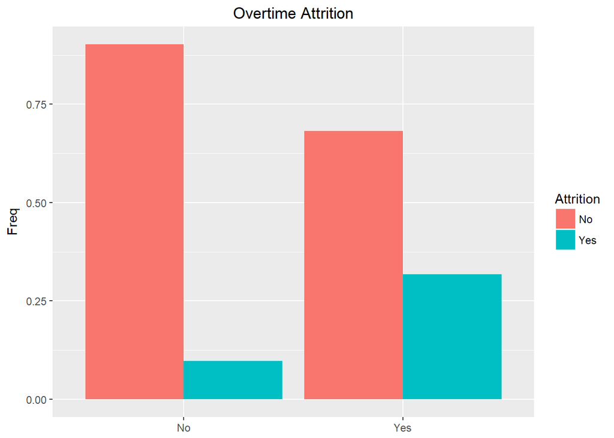

```r
#Plotting Attrition Perctages for Categorical Variables


ggplot(data=OverTimeAttr_Prop, aes(x=Var1, y=Freq, fill=Var2)) +

  geom_bar(stat="identity", position=position_dodge()) +

  theme (axis.title.x = element_blank(), plot.title = element_text(hjust = 0.5)) +

  labs(fill = "Attrition") +

  ggtitle("Overtime Attrition")
```

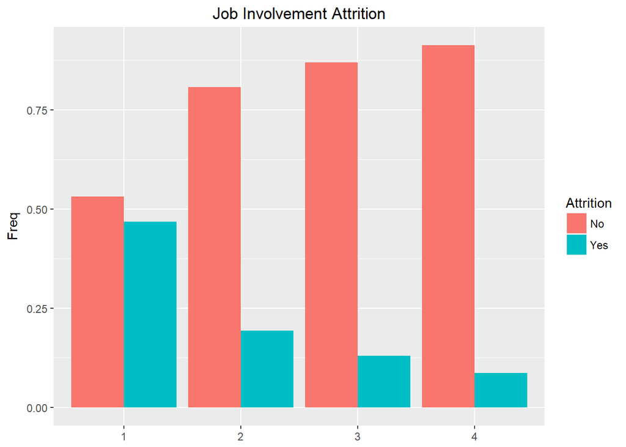

```r
  ggplot(data=JobInvAttr_Prop, aes(x=Var1, y=Freq, fill=Var2)) +

  geom_bar(stat="identity", position=position_dodge()) +

  theme (axis.title.x = element_blank(), plot.title = element_text(hjust = 0.5)) +

  labs(fill = "Attrition") +

  ggtitle("Job Involvement Attrition")
```

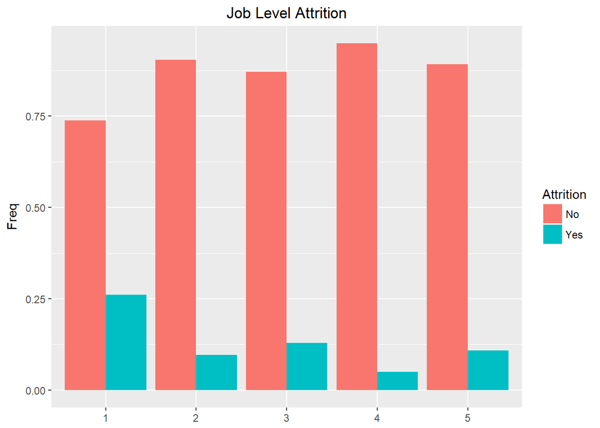

```r
  ggplot(data=JobLevAttr_Prop, aes(x=Var1, y=Freq, fill=Var2)) +

  geom_bar(stat="identity", position=position_dodge()) +

  theme (axis.title.x = element_blank(), plot.title = element_text(hjust = 0.5)) +

  labs(fill = "Attrition") +

  ggtitle("Job Level Attrition")
```

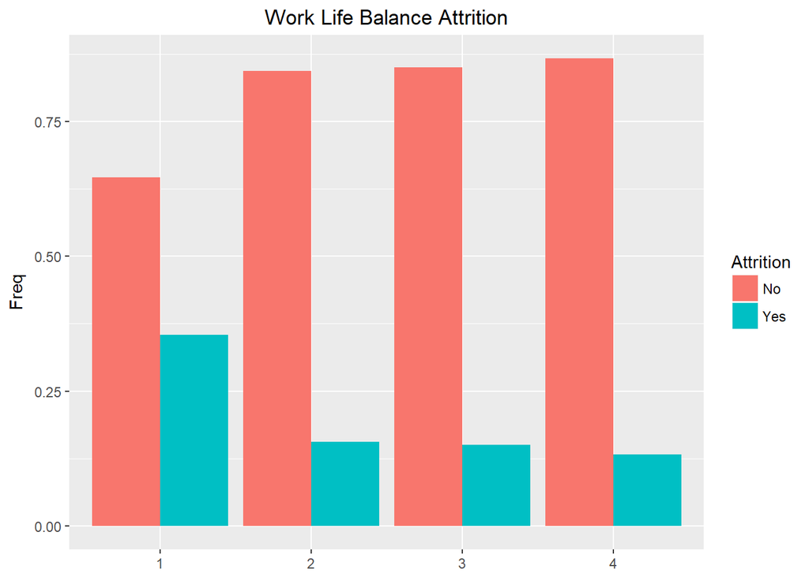

```r
  ggplot(data=WorkLifeAttr_Prop, aes(x=Var1, y=Freq, fill=Var2)) +

  geom_bar(stat="identity", position=position_dodge()) +

  theme (axis.title.x = element_blank(), plot.title = element_text(hjust = 0.5)) +

  labs(fill = "Attrition") +

  ggtitle("Work Life Balance Attrition")
```

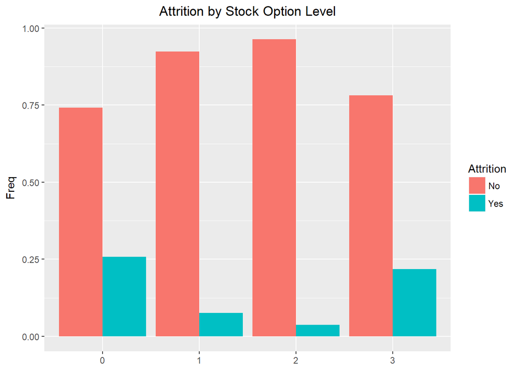

```r
ggplot(data=StockAttr_Prop, aes(x=Var1, y=Freq, fill=Var2)) +

  geom_bar(stat="identity", position=position_dodge()) +

  theme (axis.title.x = element_blank(), plot.title = element_text(hjust = 0.5)) +

  labs(fill = "Attrition") +

  ggtitle("Attrition by Stock Option Level")
```

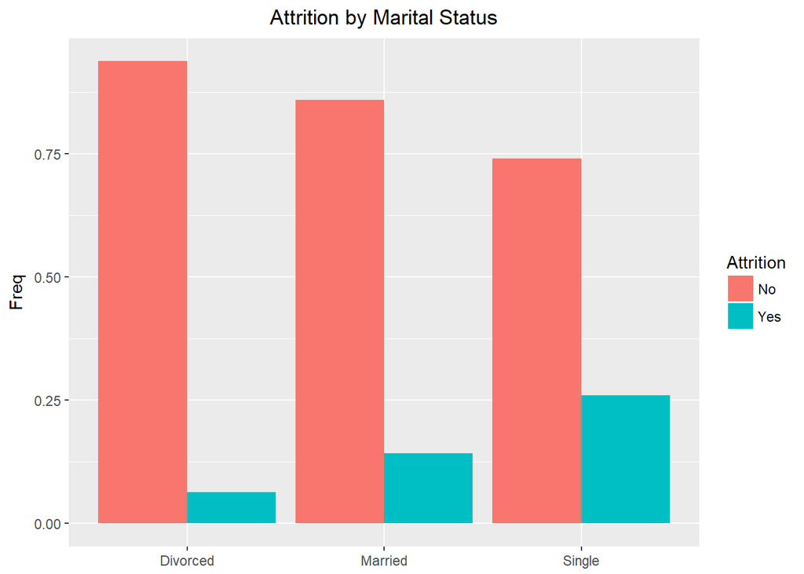

```r
ggplot(data=MaritalAttr_Prop, aes(x=Var1, y=Freq, fill=Var2)) +

  geom_bar(stat="identity", position=position_dodge()) +

  theme (axis.title.x = element_blank(), plot.title = element_text(hjust = 0.5)) +

  labs(fill = "Attrition") +

  ggtitle("Attrition by Marital Status")
```

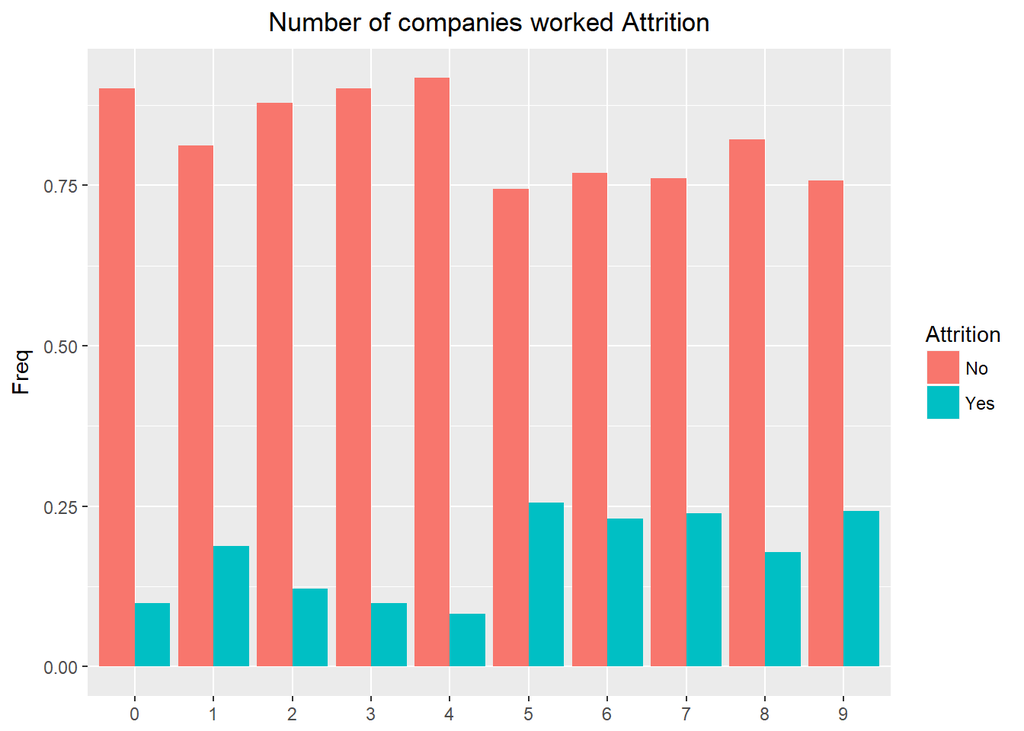

```r
ggplot(data=NumCompaniesWorkedAttr_Prop, aes(x=Var1, y=Freq, fill=Var2)) +

  geom_bar(stat="identity", position=position_dodge()) +

  theme (axis.title.x = element_blank(), plot.title = element_text(hjust = 0.5)) +

  labs(fill = "Attrition") +

  ggtitle("Number of companies worked Attrition")
```

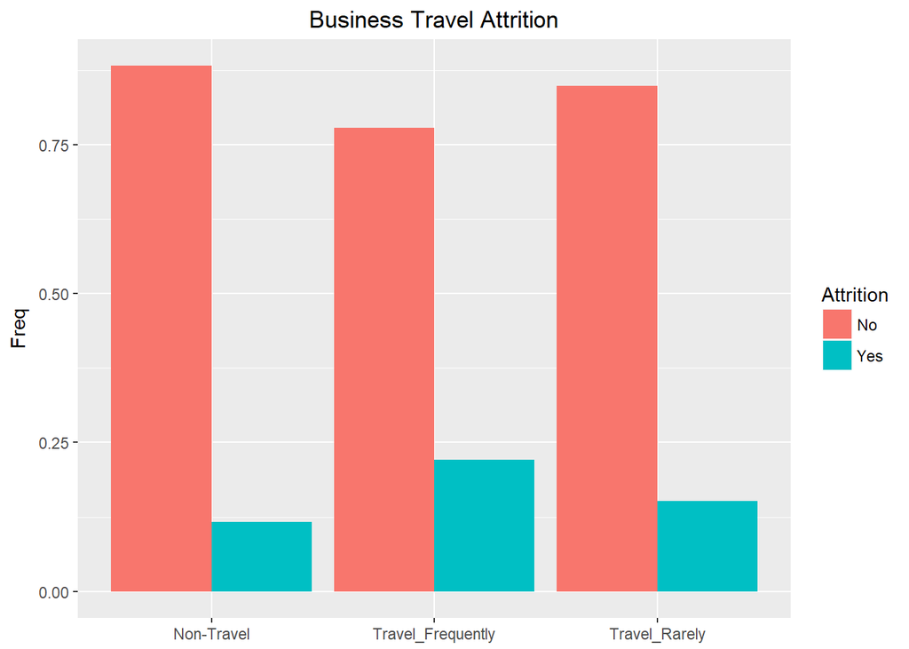

```r
ggplot(data=BusTravAttr_Prop, aes(x=Var1, y=Freq, fill=Var2)) +

  geom_bar(stat="identity", position=position_dodge()) +

  theme (axis.title.x = element_blank(), plot.title = element_text(hjust = 0.5)) +

  labs(fill = "Attrition") +

  ggtitle("Business Travel Attrition")
```

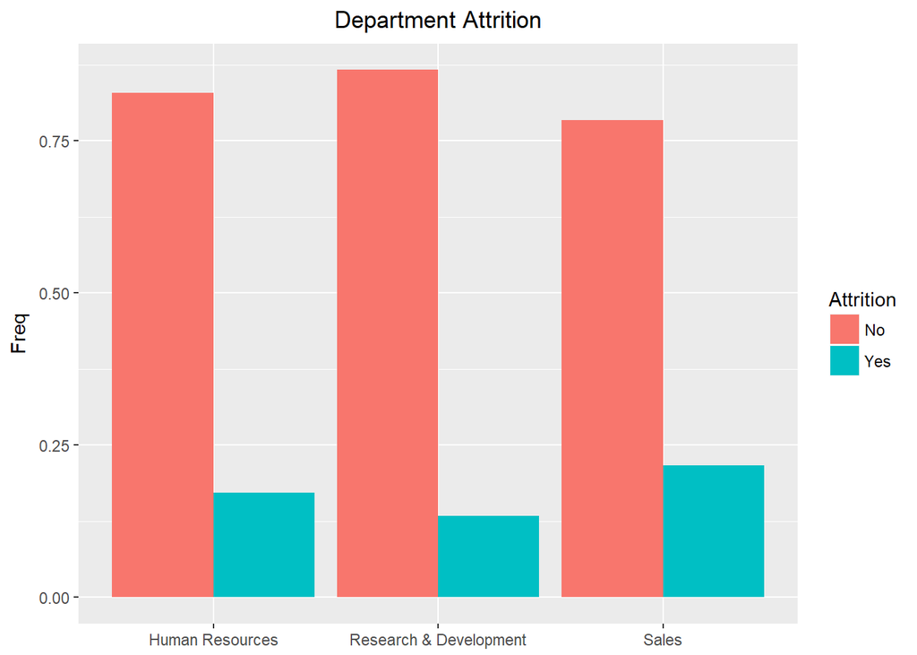

```r
ggplot(data=DeptAttr_Prop, aes(x=Var1, y=Freq, fill=Var2)) +

  geom_bar(stat="identity", position=position_dodge()) +

  theme (axis.title.x = element_blank(), plot.title = element_text(hjust = 0.5)) +

  labs(fill = "Attrition") +

  ggtitle("Department Attrition")
```

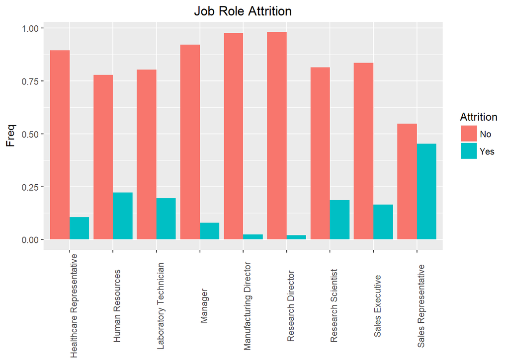

```r
ggplot(data=RoleAttr_Prop, aes(x=Var1, y=Freq, fill=Var2)) +

  geom_bar(stat="identity", position=position_dodge()) +

  theme (axis.title.x = element_blank(), plot.title = element_text(hjust = 0.5)) +

  labs(fill = "Attrition") +

  ggtitle("Job Role Attrition") +

  theme(axis.text.x=element_text(angle=90))
```

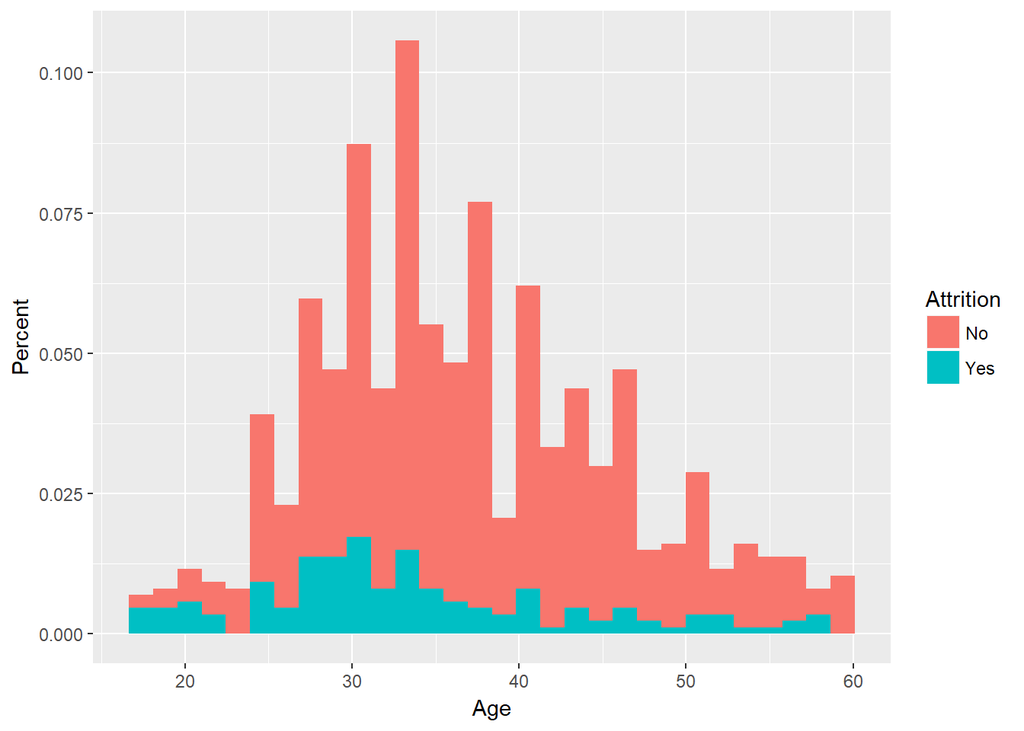

```r
#Plotting Continuous Variable Variance by Attrition

ggplot(data=df_Attrition2, aes(x=Age, fill=Attrition)) + ylab("Percent") +

  geom_histogram(aes(y=(..count..)/sum(..count..)))
```

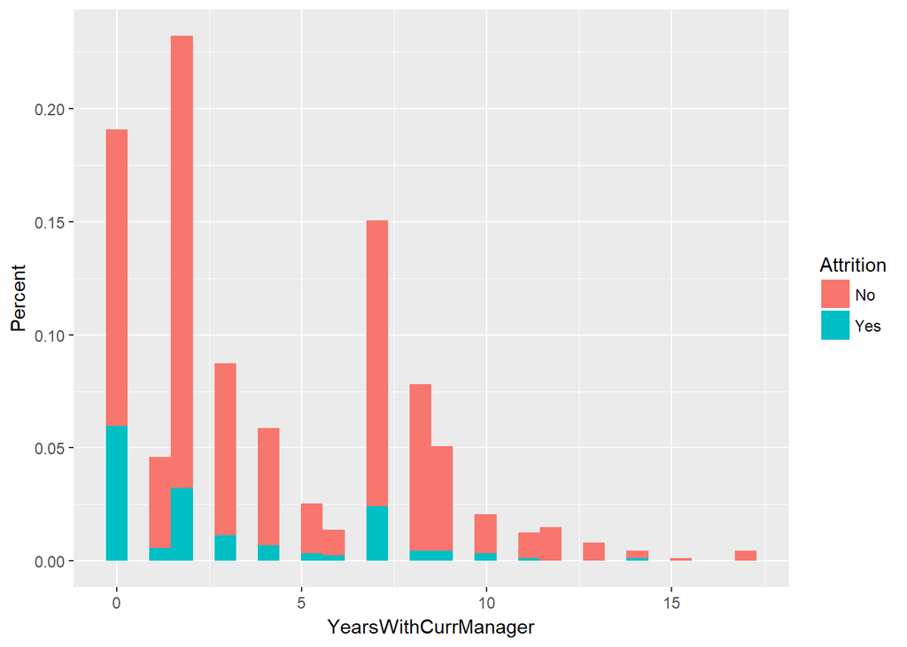

```r
ggplot(data=df_Attrition2, aes(x=YearsWithCurrManager, fill=Attrition)) + ylab("Percent") +

  geom_histogram(aes(y=(..count..)/sum(..count..)))
```

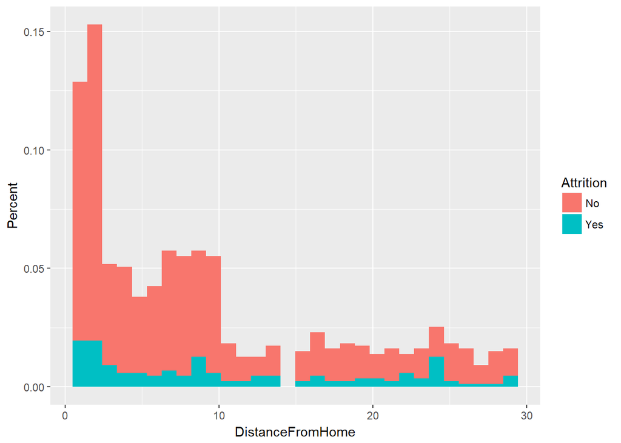

```r
ggplot(data=df_Attrition2, aes(x=DistanceFromHome, fill=Attrition)) + ylab("Percent") +

  geom_histogram(aes(y=(..count..)/sum(..count..)))
```